# Taller 10: Muestreo II en R

Estadística II

M. Constanza Ayala  
maria.ayala@uv.cl  
[Agenda una reunión aquí](https://outlook.office.com/bookwithme/user/6c3f9a95bb9d4c71abbc4d73b48d50d6@uv.cl/meetingtype/HPNElmMJ_UCckWs5QZTpdw2?anonymous&ismsaljsauthenabled&ep=mLinkFromTile)

Escuela de Sociología - Universidad de Valparaíso

02 de junio, 2026

## Pasemos lista mientras descargan los materiales y dejamos todo listo ✨

📂 **Paso 1:** Abrimos nuestro proyecto con doble clic en el archivo `.Rproj`

- Si no tienen proyecto, creamos uno: `File > New Project > New Directory > New Project` — creamos carpetas: `data`, `scripts`, `figures`, `output`

💾 **Paso 2:** Movemos el archivo **“Script Taller 10 EstadisticaII.R”** a la carpeta `scripts`

📎 **Paso 3:** Verificamos que la base **base_92_20112024.Rds** esté en la carpeta `data`

> **Todos los materiales los pueden descargar en este link: [Materiales clases](https://github.com/mconstanzaa/estadistica-ii-uv-2026/)**

## Objetivos de la clase

- Recordar los principales **tipos de muestreo probabilístico**
- Aplicar **muestreo estratificado** con el paquete `sampling`
- Aplicar **muestreo por conglomerados** con el paquete `sampling`

## ¿Qué vimos la última clase?

✅ Distinguimos los conceptos de universo, marco muestral y muestra

✅ Identificamos los tipos de muestreo probabilístico y cuándo usar cada uno

✅ Aplicamos MAS con `sample_n()` y visualizamos la distribución muestral con `map_dbl()`

💡 ¡Hoy seguimos con **diseño muestral** en R!

## Actividades prácticas

A lo largo de la clase realizaremos **dos actividades prácticas**, una por tipo de muestreo.

No tienen nota, pero recomiendo resolverlas en un script aparte para que quede como material de estudio.

- Crea un script nuevo e incluye un título, tu nombre, correo y fecha:

```r
# Actividades Taller 10 Estadística II --------------------------------------------
# M. Constanza Ayala (maria.ayala@uv.cl)
# 02-06-2026
```

## Universo, marco muestral y muestra

- **Universo:** conjunto completo de elementos que la investigación busca estudiar — es el referente teórico de la inferencia.
- **Marco muestral:** lista operacional desde la cual se extrae la muestra (idealmente cubre todo el universo).
- **Muestra:** subconjunto seleccionado del marco. Si la selección fue aleatoria → se puede generalizar al universo con error conocido.

## CEP 92

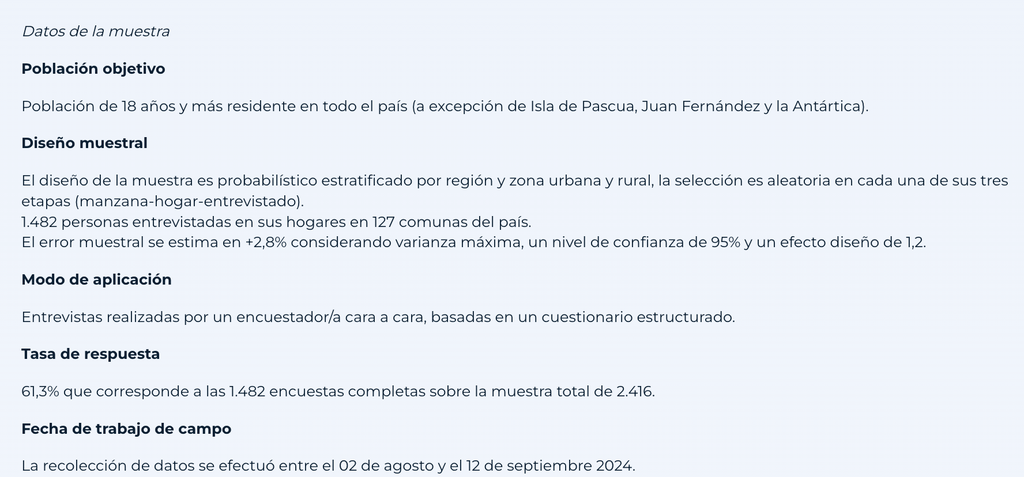

## Diseño muestral

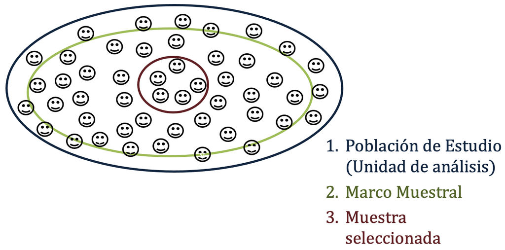

## Tipos de muestreo probabilístico: definiciones

- **Aleatorio simple (MAS)** Todos los casos tienen igual probabilidad de ser seleccionados. No se usa información auxiliar de la población.
- **Sistemático** Se selecciona cada k-ésimo elemento de la lista (k = N/n). Parte de un primer sujeto elegido al azar.
- **Estratificado** La población se divide en subpoblaciones no sobrepuestas (estratos) y se sortea de forma independiente dentro de cada uno.
- **Por conglomerados** La población se divide en grupos naturales (comunas, escuelas, regiones) y se seleccionan aleatoriamente algunos grupos completos.
- **Multietápico** Combina dos o más de los métodos anteriores sobre distintas unidades — por ejemplo, estratos de regiones → conglomerados de manzanas → MAS de individuos. Es el diseño de la CEP.

> En este taller implementamos en R: **estratificado** y **conglomerados**.

## Carguemos los paquetes y la base de datos

```r
library(tidyverse)
library(haven)
library(sampling)

data <- readRDS("data/base_92_20112024.Rds")

data %>% glimpse()
```

```
Rows: 1,482
Columns: 157
$ id_bu             <chr> "1-92", "2-92", "3-92", "4-92", "5-92", "6-92", "7-9…
$ id_bu_encuesta    <dbl> 1, 2, 3, 4, 5, 6, 7, 8, 9, 10, 11, 12, 13, 14, 15, 1…
$ encuesta          <dbl> 92, 92, 92, 92, 92, 92, 92, 92, 92, 92, 92, 92, 92, …
$ encuesta_a        <dbl> 2024, 2024, 2024, 2024, 2024, 2024, 2024, 2024, 2024…
$ encuesta_m        <dbl> 8, 8, 8, 8, 8, 8, 8, 8, 8, 8, 8, 8, 8, 8, 8, 8, 8, 8…
$ pond              <dbl> 0.2096586, 1.2242271, 0.4620447, 1.6158843, 1.249230…
$ secu              <dbl> 92071, 92173, 92193, 92173, 92071, 92193, 92193, 921…
$ estrato           <dbl> 8, 20, 20, 20, 8, 20, 20, 20, 20, 20, 20, 12, 20, 10…
$ region_3          <dbl+lbl>  6, 13, 13, 13,  6, 13, 13, 13, 13, 13, 13,  8, …
$ zona_u_r          <dbl+lbl> 1, 1, 1, 1, 1, 1, 1, 1, 1, 1, 1, 1, 1, 1, 1, 1, …
$ gse               <dbl+lbl> 4, 3, 3, 3, 4, 3, 3, 2, 3, 3, 2, 4, 3, 3, 3, 3, …
$ percepcion_1_a    <dbl+lbl>  3,  3, 14,  1,  1,  5,  9, 14,  1,  1,  1,  1, …
$ percepcion_1_b    <dbl+lbl>  7,  9, 10, 10,  3, 10, 14,  9,  9,  3,  5,  3, …
```

[output cut: 144 more lines]

## Preparación: recodificar valores perdidos

Antes de trabajar con cualquier variable, recodificamos los valores no válidos como `NA`:

```r
data <- data %>%
  mutate(
    democracia_19 = case_when(
      democracia_19 %in% c(-8, -9) ~ NA_real_,
      TRUE ~ democracia_19
    ),
    bienestar_2 = case_when(
      bienestar_2 %in% c(-8, -9) ~ NA_real_,
      TRUE ~ bienestar_2
    )
  )
```

> `democracia_19`: preferencia entre libertades públicas (1) y orden público (10) · `bienestar_2`: satisfacción con la vida (1–10).

## Valores de referencia

Antes de simular muestras, calculamos los estadísticos en la base completa. La CEP 92 es en sí misma una muestra, no la población chilena, pero para este ejercicio **la trataremos como nuestra población de referencia**: extraeremos submuestras de ella y las compararemos.

```r
data %>%
  summarise(
    media_democracia = mean(democracia_19, na.rm = TRUE),
    media_satisf     = mean(bienestar_2,   na.rm = TRUE),
    n                = n()
  )
```

```
# A tibble: 1 × 3
  media_democracia media_satisf     n
             <dbl>        <dbl> <int>
1             8.21         7.56  1482
```

> Esto nos permitirá ver cómo varía una estimación muestral respecto al valor que la muestra completa entrega, simulando la lógica de la inferencia estadística.

## Muestreo Estratificado

> La población se divide en **estratos homogéneos** y se extrae una muestra aleatoria dentro de cada uno, asegurando su representación proporcional en la muestra final.

**¿Por qué estratificar?**

- Con MAS puro, un grupo pequeño podría quedar con muy pocos casos por azar. El muestreo estratificado **garantiza** que cada subgrupo esté representado en la proporción que corresponde a su tamaño real en la población.
- En R usamos `strata()` del paquete `sampling`.

## Estratificado por sexo

```r
# Revisamos la distribución del estrato
table(data$sexo)
```

```
  1   2
577 905
```

```r
prop.table(table(data$sexo))
```

```
        1         2
0.3893387 0.6106613
```

```r
# 1 = Hombre (39%), 2 = Mujer (61%)
```

```r
# La base debe estar ordenada por la variable de estrato
data <- data %>% arrange(sexo)

#Incorporamos la semilla para reproducibilidad
set.seed(2026)

# Definimos el tamaño proporcional: n = 150 → ~39% Hombre, ~61% Mujer
estratos <- strata(data,
                   stratanames = c("sexo"),  # variable de estrato
                   size = c(58, 92),         # nᵢ por estrato (proporcional a 150)
                   method = "srswor")        # muestreo sin reemplazo dentro de cada estrato

table(estratos$sexo)
```

```
 1  2
58 92
```

## Extraer la muestra estratificada

```r
# Extraemos los datos de la muestra
muestra_estrat <- getdata(data, estratos)

# Verificamos la distribución resultante
table(muestra_estrat$sexo)
```

```
 1  2
58 92
```

```r
prop.table(table(muestra_estrat$sexo))
```

```
        1         2
0.3866667 0.6133333
```

```r
# Estimamos la media de democracia_19 por estrato
muestra_estrat %>%
group_by(sexo) %>%
summarise(
  media_democracia = mean(democracia_19, na.rm = TRUE),
  n                = n()
)
```

```
# A tibble: 2 × 3
  sexo       media_democracia     n
  <dbl+lbl>             <dbl> <int>
1 1 [Hombre]             8       58
2 2 [Mujer]              8.12    92
```

## Estratificado por dos variables

También podemos estratificar por dos variables simultáneamente — por ejemplo, sexo y GSE:

```r
# Recodificamos GSE a 4 categorías (D y E juntos)
data <- data %>%
  mutate(gse_4cat = case_when(
  gse %in% c(4, 5) ~ 4,
  TRUE             ~ gse
  ))

# Ordenamos por ambas variables de estrato
data <- data %>% arrange(sexo, gse_4cat)

# 2 × 4 = 8 estratos, 10 casos por estrato
estratos_2 <- strata(data,
                   stratanames = c("sexo", "gse_4cat"),
                   size = rep(10, 8),
                   method = "srswor")

muestra_estrat_2 <- getdata(data, estratos_2)
table(muestra_estrat_2$sexo, muestra_estrat_2$gse_4cat)
```

```
     1  2  3  4
  1 10 10 10 10
  2 10 10 10 10
```

## Actividad práctica 2 - Estratificado

En una sección del script llamada `Muestreo Estratificado`:

1. Revisa la distribución de `zona_u_r` con `table()` y `prop.table()`.
2. Calcula manualmente el tamaño proporcional para cada estrato con n = 150 e inclúyelo como comentario (`#`) en el script.
3. Ordena la base por `zona_u_r` con `arrange()`, fija la semilla con `set.seed(1234)` y extrae una muestra estratificada con `strata()` usando los tamaños que calculaste.
4. Extrae la muestra con `getdata()` y verifica la distribución resultante con `table()` y `prop.table()`.
5. Calcula la media de `bienestar_2` por zona con `group_by()` y `summarise()`. Escribe como comentario (`#`) qué diferencias observas.

## Muestreo por Conglomerados

> La población se divide en **grupos naturales o conglomerados** (comunas, escuelas, regiones) y se seleccionan aleatoriamente algunos de estos grupos. Todos los elementos dentro de los grupos seleccionados conforman la muestra, o bien se realiza una segunda etapa de selección dentro de ellos.

**¿Cuándo usarlo?**

- Cuando la población está geográficamente dispersa y contar con un marco completo de individuos es inviable o muy costoso. Es el diseño más común en encuestas nacionales cara a cara (como la CEP).

## Conglomerados: selección de grupos

```r
# Revisamos las macro-zonas disponibles como conglomerados
table(data$region_3)
```

```
  1   2   3   4   5   6   7   8   9  10  11  12  13  14  15  16
 29  42  26  64 162  77  87 141  70  67  10  11 597  38  15  46
```

```r
#Incorporamos la semilla para reproducibilidad
set.seed(2026)

# Seleccionamos 3 macro-zonas al azar
muestra_conglom <- cluster(data,
                         clustername = "region_3",  # variable de conglomerado
                         size = 3,                  # número de grupos a seleccionar
                         method = "srswor")

# Extraemos los datos de las zonas seleccionadas
muestra_conglom_final <- getdata(data, muestra_conglom)

# ¿Qué macro-zonas fueron seleccionadas?
unique(muestra_conglom_final$region_3)
```

```
<labelled<double>[3]>: Región (nombre)
[1]  1  9 13

Labels:
 value              label
     1           Tarapacá
     2        Antofagasta
     3            Atacama
     4           Coquimbo
     5         Valparaíso
     6         O'Higgins'
     7              Maule
     8             Biobío
     9       La Araucanía
    10          Los Lagos
    11              Aysén
    12         Magallanes
    13      Metropolitana
    14           Los Ríos
    15 Arica y Parinacota
    16              Ñuble
```

## Conglomerados: segunda etapa

En el muestreo por conglomerados en dos etapas, dentro de cada grupo seleccionado se realiza una segunda selección aleatoria:

```r
# Segunda etapa: 30 casos por macro-zona seleccionada
muestra_2etapas <- muestra_conglom_final %>%
  group_by(region_3) %>%
  slice_sample(n = 30) %>%
  ungroup()

table(muestra_2etapas$region_3)
```

```
 1  9 13
29 30 30
```

```r
# También podemos seleccionar una proporción en vez de un número fijo
muestra_2etapas_prop <- muestra_conglom_final %>%
  group_by(region_3) %>%
  slice_sample(prop = 0.50) %>%  # 50% de cada grupo
  ungroup()

table(muestra_2etapas_prop$region_3)
```

```
  1   9  13
 14  35 298
```

## Actividad práctica 3 - Conglomerados

En una sección del script llamada `Muestreo por Conglomerados`:

1. Fija la semilla con `set.seed(1234)` y selecciona **4 macro-zonas** al azar con `cluster()` usando `region_3` como conglomerado.
2. Extrae los datos con `getdata()` y verifica qué macro-zonas fueron seleccionadas con `unique()`.
3. Aplica una segunda etapa seleccionando el **40%** de los casos dentro de cada macro-zona con `slice_sample(prop = 0.40)`. Verifica la distribución con `table()`.
4. Calcula la media de `bienestar_2` (satisfacción con la vida) en la muestra de dos etapas con `summarise()`. Escribe como comentario (`#`) cómo se compara con el valor poblacional calculado al inicio de la clase.

## ❓ Preguntas y aclaraciones

💬 **¿Dudas sobre lo visto hoy?**

- Tómense un momento para reflexionar y compartir preguntas sobre el contenido.
- Espacio para responder inquietudes y aclarar conceptos clave.

## Resumen clase de hoy

✅ Aplicamos muestreo estratificado con `strata()` y `getdata()`

✅ Aplicamos muestreo por conglomerados con `cluster()` en dos etapas

## 📆 Próxima sesión

- Pruebas de hipótesis

## 📚 Sugerencias lecturas para reforzar R

- Wickham & Grolemund. R for Data Science (acceso en línea biblioteca, en español: https://es.r4ds.hadley.nz/)
- [AnalizaR Datos Políticos](https://arcruz0.github.io/libroadp/index.html)
- [YaRrr! The Pirate’s Guide to R](https://bookdown.org/ndphillips/YaRrr/)